# Глава 5. Сети: основные понятия

# WLAN

Беспроводная сеть LAN (WLAN) аналогична сети LAN, однако в ней для подключения пользователей и устройств на небольшой географической территории вместо кабелей используется беспроводная связь. Передача данных в сети WLAN между беспроводными устройствами осуществляется с помощью радиосигналов.

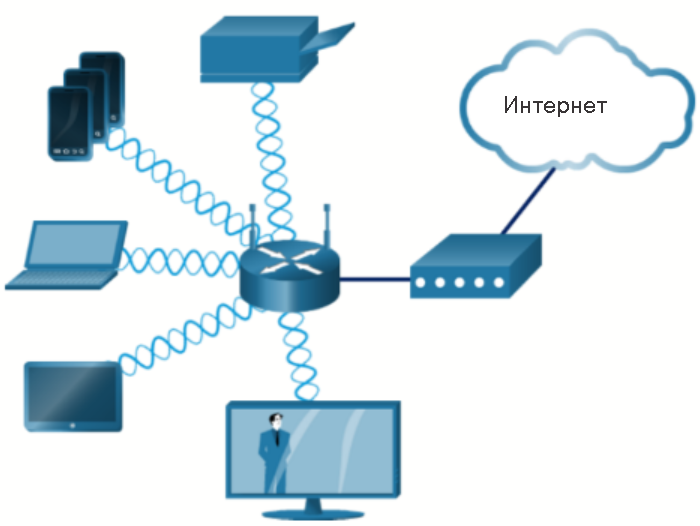

# WMN

Беспроводная ячеистая сеть (WMN) использует несколько точек доступа для расширения покрытия сети WLAN. В топологии присутствует беспроводной маршрутизатор. Две беспроводных точки доступа расширяют покрытие сети WLAN внутри дома. Коммерческие предприятия и муниципальные организации также могут использовать сети WMN для быстрого расширения зоны покрытия.

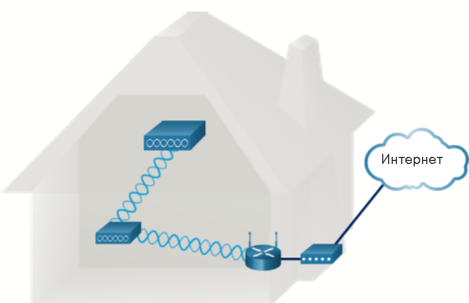

# MAN

Муниципальная сеть (MAN) - это сеть в пределах квартала или города. Сеть состоит из нескольких зданий, подключенных по беспроводной сети или по оптоволоконным линиям.

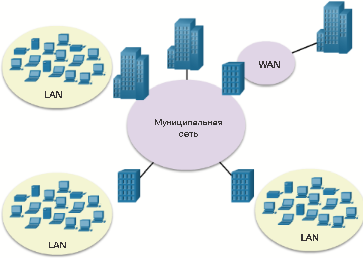

# WAN

Глобальная сеть (WAN) объединяет несколько сетей, рассредоточенных в различных географических регионах, Физические лица и организации получают доступ к WAN через операторов связи. Оператор связи обеспечивает доступ ваших стационарных или мобильных устройств к крупнейшей сети WAN, т. е. к сети Интернет. На рисунке показаны сети из Москвы и Токио, соединенные через Интернет.

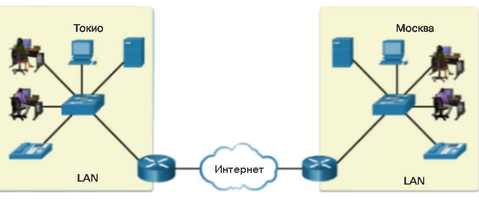

# VPN

Виртуальная частная сеть (VPN) используется для защищенного подключения к другой сети через открытую сеть (например, Интернет). Чаще всего сети VPN используют для доступа удаленных работников к закрытой корпоративной сети. Удаленные работники - это пользователи сети, работающие за пределами объекта или удаленно. На рисунке жирной линией показано VPN-подключение удаленного работника 1 к маршрутизатору в центральном офисе компании. Удаленный работник 1 безопасно входит в сеть компании с помощью программного обеспечения VPN. Удаленный работник 2 не использует защищенное подключение и не сможет получить доступ к ресурсам компании.

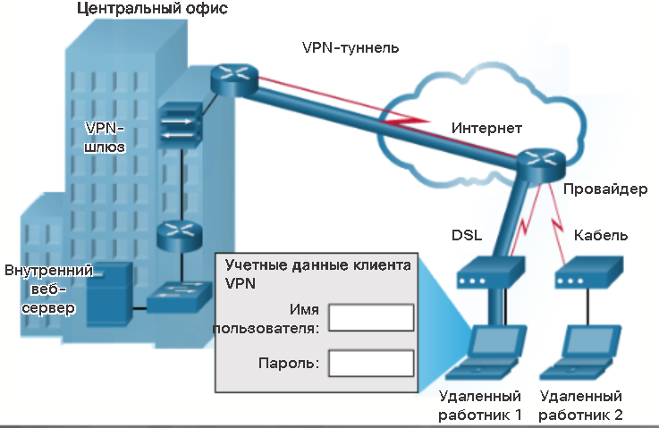

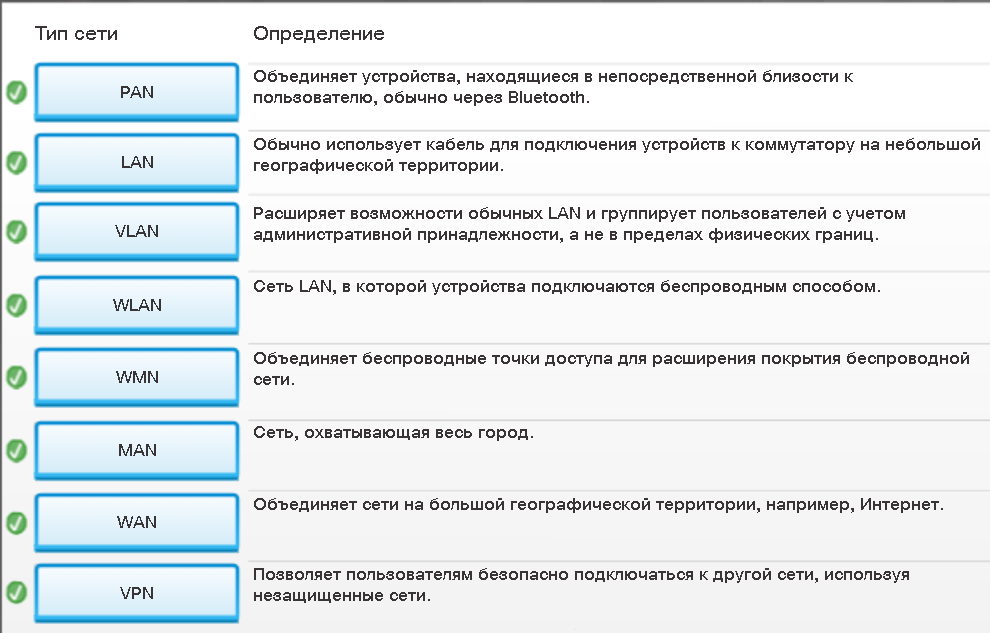

# Краткая история технологий подключения

В 90-х годах скорости подключения к Интернету были ниже, чем сегодня. В наше время пропускная способность позволяет передавать голос, видео и данные. Для коммутируемого доступа нужен либо внутренний модем, установленный в компьютере, либо внешний модем, подключенный через USB. Линейный порт модема подключается к телефонной розетке с разъемом RJ-11. После физической установки модема его необходимо подключить к одному из программных COM-портов компьютера. Кроме того в модеме необходимо настроить параметры набора номера, например, код выхода на внешнюю телефонную линию и код города.

Мастер установки подключений или мастер сетевых подключений позволяет настроить подключение к серверу интернет-провайдера. Сегодня вместо телефонной линии для доступа в Интернет используется широкополосная связь:

Аналоговый телефон

При доступе к Интернету через аналоговый телефон данные передаются по стандартной телефонной линии. В этой схеме используется аналоговый модем, который «созванивается» с другим модемом, расположенным на удаленном объекте. Такой тип подключения называют коммутируемым доступом.

Цифровая сеть с интегрированными услугами

Цифровая сеть с интегрированными услугами (Integrated Services Digital Network, ISDN) использует несколько каналов и может предоставлять различные услуги. Поэтому ISDN относится к одному из видов широкополосной связи. Стандарт ISDN предполагает использование нескольких каналов для передачи голоса, видео и данных по обычным телефонным линиям. Пропускная способность ISDN больше, чем при традиционном коммутируемом доступе.

Широкополосный доступ

Широкополосная технология подразумевает использование различных частот для передачи нескольких сигналов в одной среде передачи. Например, по коаксиальному кабелю, который используется для доставки кабельного телевидения, можно наряду с сотнями ТВ-каналов передавать данные компьютерной сети. Ваш мобильный телефон может принимать голосовые вызовы и одновременно с этим использовать веб-браузер.

К наиболее распространенным типам широкополосных подключений можно отнести кабельную линию, цифровую абонентскую линию (Digital Subscriber Line, DSL), ISDN, спутниковые и мобильные подключения. На рисунке показано оборудование, используемое для подключения к широкополосной сети или широкополосной передачи данных.

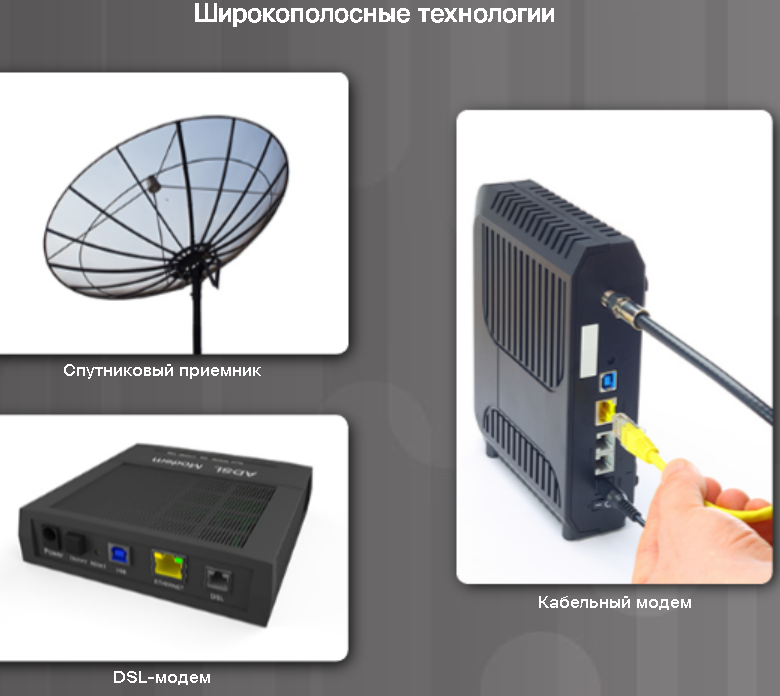

# Цифровая абонентская линия (DSL), кабельная и оптоволоконная линии

Как в случае с DSL, так и в случае с кабельной линией для подключения к Интернету через интернет-провайдера используется модем, что показано на рисунке. DSL-модем подключает сеть пользователя непосредственно к цифровой инфраструктуре телефонной компании. Кабельный модем подключает сеть пользователя к оператору кабельной сети.

Цифровая абонентская линия (DSL)

DSL относится к непрерывно доступным службам, т. е. нет необходимости каждый раз набирать номер для подключения к Интернету. Голос и данные передаются по медному телефонному кабелю на разных частотах. Специальный фильтр предотвращает взаимные помехи между сигналами DSL и телефонными сигналами.

Кабельная линия

Для кабельного подключения к Интернету телефонная линия не нужна. В этом случае используется коаксиальный кабель, изначально предназначенный для передачи кабельного телевидения. Кабельный модем подключает ваш компьютер к оператору кабельной сети. Компьютер можно подключать непосредственно к кабельному модему. Однако если подключить к модему маршрутизатор, то через него к Интернету можно будет подключить несколько компьютеров.

Оптоволоконная линия

Оптоволоконные кабели изготавливаются из стекла или пластмассы, для передачи данных в них используется свет. У них очень высокая пропускная способность, позволяющая передавать большие объемы данных. Данные, передаваемые в рамках вашего подключения к Интернету, в определенный момент проходят через оптоволоконные сегменты сети. Оптоволоконные кабели используются в магистральных сетях, в крупных корпоративных сетях и в больших ЦОД. Устаревшая инфраструктура медных кабелей, окружающая домовладения и офисы, все чаще уступает место оптоволоконным кабелям. В качестве примера на рисунке показано кабельное подключение с использованием гибридной оптоволоконно-коаксиальной сети (Hybrid Fiber Coaxial, HFC), где на участке последней мили к дому пользователя используется оптоволоконный кабель. В самом доме сеть снова переходит на медный коаксиальный кабель.

Доступные варианты подключения зависят от географического положения и наличия операторов связи.

## DSL-модемы и кабельные модемы

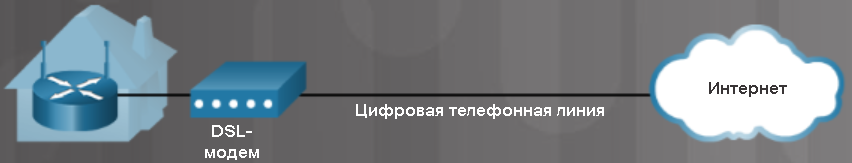

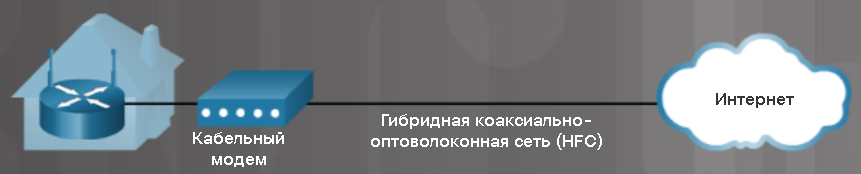

[figure not shown]